# Multi-Trait BLUP

# Disclaimer

This is notebook explains in more detail how to solve a problem with multi-trait BLUP of breeding values. The terms ‘multi-trait’ and ‘multi-variate’ are used as synonyms.

# Data

The same dataset as in Problems 1 and 2 of Exercise 9 (https://charlotte-ngs.github.io/lbgfs2020/ex/lbgfs2020_w10_ex09.pdf) is used. The dataset is shown in the following table.

```r
n_nr_trait <- 2
n_nr_founder <- 3
n_nr_animal <- 8
n_nr_observation <- n_nr_animal - n_nr_founder
tbl_data_sol12p01 <- tibble::tibble(Animal = c((n_nr_founder+1):n_nr_animal),
                                        Sex = c("Male", "Female","Female","Male","Male"),
                                        Sire = c(1,3,1,4,3),
                                        Dam = c(NA,2,2,5,6),
                                        WWG = c(4.5,2.9,3.9,3.5,5.0),
                                        PWG = c(6.8,5.0,6.8,6.0,7.5))
tbl_data_sol12p01
```

| Animal | Sex | Sire | Dam | WWG | PWG |
| --- | --- | --- | --- | --- | --- |
| 4 | Male | 1 | NA | 4.5 | 6.8 |
| 5 | Female | 3 | 2 | 2.9 | 5.0 |
| 6 | Female | 1 | 2 | 3.9 | 6.8 |
| 7 | Male | 4 | 5 | 3.5 | 6.0 |
| 8 | Male | 3 | 6 | 5.0 | 7.5 |

The variables defined before the data have the following meaning

- `n_nr_trait`: number of traits - traits are WWG and PWG, hence it is 2
- `n_nr_founder`: number of founders - animals without parents
- `n_nr_animal`: total number of animals in the pedigree
- `n_nr_observation`: number of observations for a single trait

# Parameter

The parameters that are given consist of the genetic variance-covariance matrix $G_0$ between the two traits WWG and PWG and the variance-covariance matrix $R_0$ between the traits. These matrices are

```r
(mat_G0 <- matrix(data = c(20,18,18,40), nrow = n_nr_trait, byrow = TRUE))
```

```
     [,1] [,2]
[1,]   20   18
[2,]   18   40
```

and

```r
(mat_R0 <- matrix(data = c(40,11,11,30), nrow = n_nr_trait, byrow = TRUE))
```

```
     [,1] [,2]
[1,]   40   11
[2,]   11   30
```

# Model

The multi-trait model for estimating fixed effects and for predicting breeding values looks the same as the model for only one trait.

$$y = X\beta + Zu + e$$

Although, the model looks the same, the components must be adapted to the situation of multiple traits. This adaptation is different for the vectors $y$, $\beta$, $u$ and $e$ in the model compared to the matrices $X$ and $Z$.

## Vectors

For the vectors, the versions of the single traits are just appended to each other. For the vector $y$ this means that

$$y = \begin{bmatrix} y_1 \\ y_2 \end{bmatrix}$$
where $y_1$ are all the observations for the trait ‘WWG’ and $y_2$ are all the observations for the trait ‘PWG’. Inserting the numbers this means

```r
(y1 <- tbl_data_sol12p01$WWG)
```

```
[1] 4.5 2.9 3.9 3.5 5.0
```

and

```r
(y2 <- tbl_data_sol12p01$PWG)
```

```
[1] 6.8 5.0 6.8 6.0 7.5
```

and appending $y_2$ at the end of $y_1$ leads to

```r
(y <- c(y1,y2))
```

```
 [1] 4.5 2.9 3.9 3.5 5.0 6.8 5.0 6.8 6.0 7.5
```

The same is done for all the other vectors. Because, ‘sex’ with two levels ‘female’ and ‘male’ is the only fixed effect, the vector $\beta$ for the multi-trait model looks as follows

$$\beta = \begin{bmatrix} \beta_{M,WWG} \\\beta_{F,WWG} \\\beta_{M,PWG} \\\beta_{F,PWG}\end{bmatrix}$$

The vector $u$ of breeding values contains as components all breeding values for all animals in the pedigree.

$$u = \begin{bmatrix} u_{WWG} \\ u_{PWG} \end{bmatrix}$$
where $u_{WWG}$ is the vector with breeding values for ‘WWG’ of all animals in the pedigree and $u_{PWG}$ is the vector with breeding values for ‘PWG’ of all animals in the pedigree.

## Matrices

The dimensions of the design matrices must match the number of observations and the length of their associated effects. Hence for the matrix $X$ which has the vector $\beta$ of fixed effects as the associated effect, it must have 4 columns as their are two fixed effect levels for each of the two traits.

The matrix $X$ is the design matrix for the vector of fixed effects $\beta$.

$$X = \left[
\begin{array}{lr}
X_1 & 0 \\
0 & X_2
\end{array}
\right]$$

where $X_1$ and $X_2$ are the design matrix for the fixed effects for the single traits ‘WWG’ and ‘PWG’.

```r
mat_X1 <- matrix(c(1, 0,
                   0, 1,
                   0, 1,
                   1, 0,
                   1, 0), ncol = n_nr_trait, byrow = TRUE)
mat_X2 <- mat_X1
mat_Xzero <- matrix(0, nrow = n_nr_observation, ncol = n_nr_trait)
(mat_X <- rbind(cbind(mat_X1, mat_Xzero), cbind(mat_Xzero, mat_X2)))
```

```
      [,1] [,2] [,3] [,4]
 [1,]    1    0    0    0
 [2,]    0    1    0    0
 [3,]    0    1    0    0
 [4,]    1    0    0    0
 [5,]    1    0    0    0
 [6,]    0    0    1    0
 [7,]    0    0    0    1
 [8,]    0    0    0    1
 [9,]    0    0    1    0
[10,]    0    0    1    0
```

The matrix $Z$ links breeding values to observations.

```r
mat_Zfounder <- matrix(0, nrow = n_nr_observation, ncol = n_nr_founder)
mat_Z1 <- cbind(mat_Zfounder, diag(1, nrow = n_nr_observation))
mat_Z2 <- mat_Z1
mat_Zzero <- matrix(0, nrow = n_nr_observation, ncol = n_nr_animal)
(mat_Z <- rbind(cbind(mat_Z1, mat_Zzero), cbind(mat_Zzero, mat_Z2)))
```

```
      [,1] [,2] [,3] [,4] [,5] [,6] [,7] [,8] [,9] [,10] [,11] [,12] [,13] [,14] [,15] [,16]
 [1,]    0    0    0    1    0    0    0    0    0     0     0     0     0     0     0     0
 [2,]    0    0    0    0    1    0    0    0    0     0     0     0     0     0     0     0
 [3,]    0    0    0    0    0    1    0    0    0     0     0     0     0     0     0     0
 [4,]    0    0    0    0    0    0    1    0    0     0     0     0     0     0     0     0
 [5,]    0    0    0    0    0    0    0    1    0     0     0     0     0     0     0     0
 [6,]    0    0    0    0    0    0    0    0    0     0     0     1     0     0     0     0
 [7,]    0    0    0    0    0    0    0    0    0     0     0     0     1     0     0     0
 [8,]    0    0    0    0    0    0    0    0    0     0     0     0     0     1     0     0
 [9,]    0    0    0    0    0    0    0    0    0     0     0     0     0     0     1     0
[10,]    0    0    0    0    0    0    0    0    0     0     0     0     0     0     0     1
```

# Solutions

Solutions are obtained by mixed-model equations.

$$\begin{bmatrix}
X^TR^{-1}X & X^TR^{-1}Z \\
Z^TR^{-1}X & Z^TR^{-1}Z + G^{-1}
\end{bmatrix}
\begin{bmatrix}
\hat{\beta} \\
\hat{u}
\end{bmatrix}
=
\begin{bmatrix}
X^TR^{-1}y \\
Z^TR^{-1}y
\end{bmatrix}$$

In the multi-trait case, we have to use the general form of mixed-model equations, because the variance-covariance matrix of the random error terms does not have the simple form of $R = I *\sigma_e^2$. In the multi-trait case the variance-covariance matrix $R = R_0 \otimes I_n$ where $n$ is the number of observations for a single trait. For the mixed model equations, the inverse $R^{-1}$ of $R$ is needed. This can be computed as

$$R^{-1} = R_0^{-1} \otimes I_n$$

```r
mat_R0inv <- solve(mat_R0)
(mat_Rinv <- mat_R0inv %x% diag(1, nrow = n_nr_observation))
```

```
             [,1]        [,2]        [,3]        [,4]        [,5]        [,6]        [,7]        [,8]        [,9]       [,10]
 [1,]  0.02780352  0.00000000  0.00000000  0.00000000  0.00000000 -0.01019462  0.00000000  0.00000000  0.00000000  0.00000000
 [2,]  0.00000000  0.02780352  0.00000000  0.00000000  0.00000000  0.00000000 -0.01019462  0.00000000  0.00000000  0.00000000
 [3,]  0.00000000  0.00000000  0.02780352  0.00000000  0.00000000  0.00000000  0.00000000 -0.01019462  0.00000000  0.00000000
 [4,]  0.00000000  0.00000000  0.00000000  0.02780352  0.00000000  0.00000000  0.00000000  0.00000000 -0.01019462  0.00000000
 [5,]  0.00000000  0.00000000  0.00000000  0.00000000  0.02780352  0.00000000  0.00000000  0.00000000  0.00000000 -0.01019462
 [6,] -0.01019462  0.00000000  0.00000000  0.00000000  0.00000000  0.03707136  0.00000000  0.00000000  0.00000000  0.00000000
 [7,]  0.00000000 -0.01019462  0.00000000  0.00000000  0.00000000  0.00000000  0.03707136  0.00000000  0.00000000  0.00000000
 [8,]  0.00000000  0.00000000 -0.01019462  0.00000000  0.00000000  0.00000000  0.00000000  0.03707136  0.00000000  0.00000000
 [9,]  0.00000000  0.00000000  0.00000000 -0.01019462  0.00000000  0.00000000  0.00000000  0.00000000  0.03707136  0.00000000
[10,]  0.00000000  0.00000000  0.00000000  0.00000000 -0.01019462  0.00000000  0.00000000  0.00000000  0.00000000  0.03707136
```

The matrix $G^{-1}$ in the mixed model equations corresponds to the inverse of the variance-covariance matrix of all breeding values and is computed as

$$G^{-1} = G_0^{-1} \otimes A^{-1}$$

```r
mat_G0inv <- solve(mat_G0)
(ped <- pedigreemm::pedigree(sire = c(rep(NA, n_nr_founder), tbl_data_sol12p01$Sire),
                             dam = c(rep(NA, n_nr_founder), tbl_data_sol12p01$Dam),
                             label = as.character(1:n_nr_animal)))
```

|  | sire | dam |
| --- | --- | --- |
| 1 | NA | NA |
| 2 | NA | NA |
| 3 | NA | NA |
| 4 | 1 | NA |
| 5 | 3 | 2 |
| 6 | 1 | 2 |
| 7 | 4 | 5 |
| 8 | 3 | 6 |

```r
mat_Ainv <- as.matrix(pedigreemm::getAInv(ped = ped))
mat_Ginv <- mat_G0inv %x% mat_Ainv
#round(mat_Ginv, digits = 4)
```

## Coefficient Matrix $C$

The setup of the mixed model equations starts with the coefficient matrix $C$

$$C = \begin{bmatrix}
X^TR^{-1}X & X^TR^{-1}Z \\
Z^TR^{-1}X & Z^TR^{-1}Z + G^{-1}
\end{bmatrix}
=
\begin{bmatrix}
C_{11} & C_{12} \\
C_{21} & C_{22}
\end{bmatrix}$$
with

$$C_{11} = X^TR^{-1}X$$
$$C_{12} = X^TR^{-1}Z$$
$$C_{21} = Z^TR^{-1}X$$
$$C_{22} = Z^TR^{-1}Z + G^{-1}$$
Because the matrix C is symmetric, $C_{21} = C_{12}^T$

The coefficient matrix $C$ can be constructed as

```r
mat_C11 <- t(mat_X) %*% mat_Rinv %*% mat_X
mat_C12 <- t(mat_X) %*% mat_Rinv %*% mat_Z
mat_C21 <- t(mat_Z) %*% mat_Rinv %*% mat_X
mat_C22 <- t(mat_Z) %*% mat_Rinv %*% mat_Z + mat_Ginv
mat_C <- rbind(cbind(mat_C11, mat_C12), cbind(mat_C21, mat_C22))
#round(mat_C, digits = 3)
```

## Right-Hand Side $r$

The vector $r$ consists of the right-hand side of the mixed-model equations.

$$r = \begin{bmatrix}
r_1 \\
r_2
\end{bmatrix}
=
\begin{bmatrix}
X^TR^{-1}y \\
Z^TR^{-1}y
\end{bmatrix}$$

```r
(vec_r <- rbind(t(mat_X) %*% mat_Rinv %*% y, t(mat_Z) %*% mat_Rinv %*% y))
```

```
            [,1]
 [1,] 0.15449490
 [2,] 0.06876738
 [3,] 0.62001854
 [4,] 0.36811863
 [5,] 0.00000000
 [6,] 0.00000000
 [7,] 0.00000000
 [8,] 0.05579240
 [9,] 0.02965709
[10,] 0.03911029
[11,] 0.03614458
[12,] 0.06255792
[13,] 0.00000000
[14,] 0.00000000
[15,] 0.00000000
[16,] 0.20620945
[17,] 0.15579240
[18,] 0.21232623
[19,] 0.18674699
[20,] 0.22706209
```

## Solution Vector

The solution vector $s$ is

$$s = \begin{bmatrix}
\hat{\beta} \\
\hat{u}
\end{bmatrix} = C^{-1}r$$

```r
s <- solve(mat_C, vec_r)
s
```

```
              [,1]
 [1,]  4.360866999
 [2,]  3.397261592
 [3,]  6.799897620
 [4,]  5.880295937
 [5,]  0.150915567
 [6,] -0.015392510
 [7,] -0.078391896
 [8,] -0.010238959
 [9,] -0.270331441
[10,]  0.275808258
[11,] -0.316117562
[12,]  0.243755523
[13,]  0.279597973
[14,] -0.007610071
[15,] -0.170341439
[16,] -0.012670709
[17,] -0.477830262
[18,]  0.517238387
[19,] -0.478983695
[20,]  0.391961543
```

# Reliabilities

The reliability $B_i$ of a predicted breeding value $\hat{u}_i$ of animal $i$ for a given trait is computed according to formula (7.4) on page 80 of the course notes

$$B_i = r_{u_i,\hat{u}_i}^2 = 1 - \frac{C_{ii}^{22}}{var(u_i)}$$
where $C_{ii}^{22}$ is the i-th diagnoal element of the matrix $C^{22}$ and $var(u_i)$ is the genetic additive variance of the trait for which we want to compute $B_i$

The matrix $C^{22}$ is obtained from the inverse ($C^{-1}$) of the coeffient matrix $C$ of the mixed model equations.

$$C^{-1}
=
\begin{bmatrix}
X^TR^{-1}X & X^TR^{-1}Z \\
Z^TR^{-1}X & Z^TR^{-1}Z + G^{-1}
\end{bmatrix}^{-1}
=
\begin{bmatrix}
C^{11} & C^{12} \\
C^{21} & C^{22}
\end{bmatrix}$$

For our data the matrix $C^{22}$ is extracted from $C^{-1}$ by taking the sub-matrix in the lower right corner with dimensions $16 \times 16$. The dimension is given by the number of traits (2) time the number of animals with predicted breeding values (8).

```r
mat_Cinv <- solve(mat_C)
mat_Cinv22 <- mat_Cinv[5:20,5:20]
round(mat_Cinv22, digits = 3)
```

```
        [,1]   [,2]   [,3]   [,4]   [,5]   [,6]   [,7]   [,8]   [,9]  [,10]  [,11]  [,12]  [,13]  [,14]  [,15]  [,16]
 [1,] 18.605  0.324  1.579  8.540  2.163  8.577  5.632  5.446 16.090  0.433  2.165  7.012  2.953  7.041  5.339  5.113
 [2,]  0.324 19.596 -0.480  1.002  9.390  9.725  4.700  4.310  0.433 17.424 -0.639  1.389  8.165  8.580  4.037  3.559
 [3,]  1.579 -0.480 17.893  2.302  7.655  1.120  5.074  8.451  2.165 -0.639 15.110  3.128  5.796  1.564  4.633  6.888
 [4,]  8.540  1.002  2.302 16.505  2.270  5.155  9.706  5.412  7.012  1.389  3.128 13.212  3.106  4.743  8.656  6.216
 [5,]  2.163  9.390  7.655  2.270 16.541  7.148  8.548  7.038  2.953  8.165  5.796  3.106 13.278  7.427  7.025  6.109
 [6,]  8.577  9.725  1.120  5.155  7.148 17.151  6.206  8.531  7.041  8.580  1.564  4.743  7.427 14.036  6.035  7.010
 [7,]  5.632  4.700  5.074  9.706  8.548  6.206 17.115  7.053  5.339  4.037  4.633  8.656  7.025  6.035 13.970  7.278
 [8,]  5.446  4.310  8.451  5.412  7.038  8.531  7.053 16.284  5.113  3.559  6.888  6.216  6.109  7.010  7.278 12.951
 [9,] 16.090  0.433  2.165  7.012  2.953  7.041  5.339  5.113 35.902  0.931  4.646 15.733  6.339 15.797 11.804 11.316
[10,]  0.433 17.424 -0.639  1.389  8.165  8.580  4.037  3.559  0.931 38.768 -1.374  2.978 18.208 19.106  9.014  7.980
[11,]  2.165 -0.639 15.110  3.128  5.796  1.564  4.633  6.888  4.646 -1.374 33.799  6.717 13.122  3.352 10.281 15.466
[12,]  7.012  1.389  3.128 13.212  3.106  4.743  8.656  6.216 15.733  2.978  6.717 29.725  6.665 10.516 19.253 13.515
[13,]  2.953  8.165  5.796  3.106 13.278  7.427  7.025  6.109  6.339 18.208 13.122  6.665 29.865 16.283 15.759 13.625
[14,]  7.041  8.580  1.564  4.743  7.427 14.036  6.035  7.010 15.797 19.106  3.352 10.516 16.283 31.503 13.312 15.726
[15,]  5.339  4.037  4.633  8.656  7.025  6.035 13.970  7.278 11.804  9.014 10.281 19.253 15.759 13.312 31.364 15.967
[16,]  5.113  3.559  6.888  6.216  6.109  7.010  7.278 12.951 11.316  7.980 15.466 13.515 13.625 15.726 15.967 29.159
```

Let us assume that we want to compute the reliability of the predicted breeding value for animal 1 in the trait WWG. Then we have to extract the element $C_{11}^{22}$ from the matrix $C^{22}$. This element corresponds to the element shown in the diagram below.

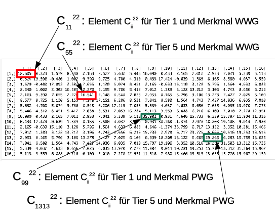

Hence the computation of reliability $B_1$ for animal 1 for the trait WWG is done as

```r
B1_WWG <- 1 - mat_Cinv22[1,1] / mat_G0[1,1]
B1_WWG
```

```
[1] 0.06976326
```

where $var(u_i)$ is the genetic additive variance of the trait WWG and is extracted from the matrix $G0$.

```r
B_1_PWG <- 1 - mat_Cinv22[9,9] / mat_G0[2,2]
B_1_PWG
```

```
[1] 0.1024554
```

For all animals and all traits, this is obtained by

```r
n_nr_sol <- dim(mat_Cinv)[1]
vec_c22_diag <- diag(mat_Cinv)[(n_nr_sol - n_nr_trait * n_nr_animal + 1):n_nr_sol]
vec_rel <- 1 - vec_c22_diag / c(rep(mat_G0[1,1], n_nr_animal), rep(mat_G0[2,2], n_nr_animal))
vec_rel
```

```
 [1] 0.06976326 0.02018124 0.10535569 0.17476719 0.17294668 0.14242750 0.14424801 0.18578089 0.10245535 0.03080923 0.15501891 0.25687708 0.25338456 0.21241863
[15] 0.21591115 0.27101269
```

# Appendix

Proof: According to the mixed-product property: $(A \otimes B)(C \otimes D) = AC \otimes BD$
$$I = RR^{-1} = (R_0 \otimes I_n)(R_0^{-1} \otimes I_n) = R_0R_0^{-1} \otimes I_nI_n = I$$